# Risk Factor Analysis

## Outcome Variable

**Outcome Variable:** haz

## Predictor Variables

**Intervention Variable:** impsan

**Adjustment Set:**

- arm
- sex
- W_mage
- meducyrs
- feducyrs
- hhwealth_quart
- hfoodsec
- W_mhtcm
- W_mwtkg
- W_mbmi
- W_nrooms
- W_nchldlt5
- W_parity
- impfloor
- safeh20
- delta_W_mage
- delta_meducyrs
- delta_feducyrs
- delta_hhwealth_quart
- delta_hfoodsec
- delta_W_mhtcm
- delta_W_mwtkg
- delta_W_mbmi
- delta_W_nrooms
- delta_W_nchldlt5
- delta_W_parity
- delta_impfloor
- delta_safeh20

## Stratifying Variables

The analysis was stratified on these variable(s):

- agecat
- studyid
- country

## Data Summary

| agecat | studyid | country | impsan | n_cell | n |
| --- | --- | --- | --- | --- | --- |
| Birth | ki0047075b-MAL-ED | BANGLADESH | 1 | 179 | 213 |
| Birth | ki0047075b-MAL-ED | BANGLADESH | 0 | 34 | 213 |
| Birth | ki0047075b-MAL-ED | BRAZIL | 1 | 59 | 60 |
| Birth | ki0047075b-MAL-ED | BRAZIL | 0 | 1 | 60 |
| Birth | ki0047075b-MAL-ED | INDIA | 1 | 15 | 40 |
| Birth | ki0047075b-MAL-ED | INDIA | 0 | 25 | 40 |
| Birth | ki0047075b-MAL-ED | NEPAL | 1 | 25 | 26 |
| Birth | ki0047075b-MAL-ED | NEPAL | 0 | 1 | 26 |
| Birth | ki0047075b-MAL-ED | PERU | 1 | 52 | 208 |
| Birth | ki0047075b-MAL-ED | PERU | 0 | 156 | 208 |
| Birth | ki0047075b-MAL-ED | SOUTH AFRICA | 1 | 0 | 95 |
| Birth | ki0047075b-MAL-ED | SOUTH AFRICA | 0 | 95 | 95 |
| Birth | ki0047075b-MAL-ED | TANZANIA, UNITED REPUBLIC OF | 1 | 0 | 118 |
| Birth | ki0047075b-MAL-ED | TANZANIA, UNITED REPUBLIC OF | 0 | 118 | 118 |
| Birth | ki1017093-NIH-Birth | BANGLADESH | 1 | 231 | 608 |
| Birth | ki1017093-NIH-Birth | BANGLADESH | 0 | 377 | 608 |
| Birth | ki1017093b-PROVIDE | BANGLADESH | 1 | 43 | 45 |
| Birth | ki1017093b-PROVIDE | BANGLADESH | 0 | 2 | 45 |
| Birth | ki1017093c-NIH-Crypto | BANGLADESH | 1 | 632 | 721 |
| Birth | ki1017093c-NIH-Crypto | BANGLADESH | 0 | 89 | 721 |
| Birth | ki1114097-CONTENT | PERU | 1 | 1 | 2 |
| Birth | ki1114097-CONTENT | PERU | 0 | 1 | 2 |
| Birth | ki1135781-COHORTS | GUATEMALA | 1 | 45 | 491 |
| Birth | ki1135781-COHORTS | GUATEMALA | 0 | 446 | 491 |
| Birth | ki1135781-COHORTS | INDIA | 1 | 1767 | 4776 |
| Birth | ki1135781-COHORTS | INDIA | 0 | 3009 | 4776 |
| Birth | ki1135781-COHORTS | PHILIPPINES | 1 | 178 | 1191 |
| Birth | ki1135781-COHORTS | PHILIPPINES | 0 | 1013 | 1191 |
| Birth | kiGH5241-JiVitA-3 | BANGLADESH | 1 | 15220 | 22431 |
| Birth | kiGH5241-JiVitA-3 | BANGLADESH | 0 | 7211 | 22431 |

[output cut: 70 more lines]

The following strata were considered:

- agecat: 24 months, studyid: ki0047075b-MAL-ED, country: BANGLADESH
- agecat: 24 months, studyid: ki0047075b-MAL-ED, country: BRAZIL
- agecat: 24 months, studyid: ki0047075b-MAL-ED, country: INDIA
- agecat: 24 months, studyid: ki0047075b-MAL-ED, country: NEPAL
- agecat: 24 months, studyid: ki0047075b-MAL-ED, country: PERU
- agecat: 24 months, studyid: ki0047075b-MAL-ED, country: SOUTH AFRICA
- agecat: 24 months, studyid: ki0047075b-MAL-ED, country: TANZANIA, UNITED REPUBLIC OF
- agecat: 24 months, studyid: ki1017093-NIH-Birth, country: BANGLADESH
- agecat: 24 months, studyid: ki1017093b-PROVIDE, country: BANGLADESH
- agecat: 24 months, studyid: ki1017093c-NIH-Crypto, country: BANGLADESH
- agecat: 24 months, studyid: ki1114097-CONTENT, country: PERU
- agecat: 24 months, studyid: ki1135781-COHORTS, country: GUATEMALA
- agecat: 24 months, studyid: ki1135781-COHORTS, country: INDIA
- agecat: 24 months, studyid: ki1135781-COHORTS, country: PHILIPPINES
- agecat: 24 months, studyid: ki1148112-LCNI-5, country: MALAWI
- agecat: 24 months, studyid: kiGH5241-JiVitA-3, country: BANGLADESH
- agecat: 24 months, studyid: kiGH5241-JiVitA-4, country: BANGLADESH
- agecat: 6 months, studyid: ki0047075b-MAL-ED, country: BANGLADESH
- agecat: 6 months, studyid: ki0047075b-MAL-ED, country: BRAZIL
- agecat: 6 months, studyid: ki0047075b-MAL-ED, country: INDIA
- agecat: 6 months, studyid: ki0047075b-MAL-ED, country: NEPAL
- agecat: 6 months, studyid: ki0047075b-MAL-ED, country: PERU
- agecat: 6 months, studyid: ki0047075b-MAL-ED, country: SOUTH AFRICA
- agecat: 6 months, studyid: ki0047075b-MAL-ED, country: TANZANIA, UNITED REPUBLIC OF
- agecat: 6 months, studyid: ki1017093-NIH-Birth, country: BANGLADESH
- agecat: 6 months, studyid: ki1017093b-PROVIDE, country: BANGLADESH
- agecat: 6 months, studyid: ki1017093c-NIH-Crypto, country: BANGLADESH
- agecat: 6 months, studyid: ki1114097-CONTENT, country: PERU
- agecat: 6 months, studyid: ki1135781-COHORTS, country: GUATEMALA
- agecat: 6 months, studyid: ki1135781-COHORTS, country: INDIA
- agecat: 6 months, studyid: ki1135781-COHORTS, country: PHILIPPINES
- agecat: 6 months, studyid: ki1148112-LCNI-5, country: MALAWI
- agecat: 6 months, studyid: kiGH5241-JiVitA-3, country: BANGLADESH
- agecat: 6 months, studyid: kiGH5241-JiVitA-4, country: BANGLADESH
- agecat: Birth, studyid: ki0047075b-MAL-ED, country: BANGLADESH
- agecat: Birth, studyid: ki0047075b-MAL-ED, country: BRAZIL
- agecat: Birth, studyid: ki0047075b-MAL-ED, country: INDIA
- agecat: Birth, studyid: ki0047075b-MAL-ED, country: NEPAL
- agecat: Birth, studyid: ki0047075b-MAL-ED, country: PERU
- agecat: Birth, studyid: ki0047075b-MAL-ED, country: SOUTH AFRICA
- agecat: Birth, studyid: ki0047075b-MAL-ED, country: TANZANIA, UNITED REPUBLIC OF
- agecat: Birth, studyid: ki1017093-NIH-Birth, country: BANGLADESH
- agecat: Birth, studyid: ki1017093b-PROVIDE, country: BANGLADESH
- agecat: Birth, studyid: ki1017093c-NIH-Crypto, country: BANGLADESH
- agecat: Birth, studyid: ki1114097-CONTENT, country: PERU
- agecat: Birth, studyid: ki1135781-COHORTS, country: GUATEMALA
- agecat: Birth, studyid: ki1135781-COHORTS, country: INDIA
- agecat: Birth, studyid: ki1135781-COHORTS, country: PHILIPPINES
- agecat: Birth, studyid: kiGH5241-JiVitA-3, country: BANGLADESH
- agecat: Birth, studyid: kiGH5241-JiVitA-4, country: BANGLADESH

### Dropped Strata

- agecat: Birth, studyid: ki0047075b-MAL-ED, country: BRAZIL
- agecat: Birth, studyid: ki0047075b-MAL-ED, country: NEPAL
- agecat: Birth, studyid: ki0047075b-MAL-ED, country: SOUTH AFRICA
- agecat: Birth, studyid: ki0047075b-MAL-ED, country: TANZANIA, UNITED REPUBLIC OF
- agecat: Birth, studyid: ki1017093b-PROVIDE, country: BANGLADESH
- agecat: Birth, studyid: ki1114097-CONTENT, country: PERU
- agecat: 6 months, studyid: ki0047075b-MAL-ED, country: BRAZIL
- agecat: 6 months, studyid: ki0047075b-MAL-ED, country: NEPAL
- agecat: 6 months, studyid: ki0047075b-MAL-ED, country: SOUTH AFRICA
- agecat: 6 months, studyid: ki0047075b-MAL-ED, country: TANZANIA, UNITED REPUBLIC OF
- agecat: 6 months, studyid: ki1017093b-PROVIDE, country: BANGLADESH
- agecat: 6 months, studyid: ki1148112-LCNI-5, country: MALAWI
- agecat: 24 months, studyid: ki0047075b-MAL-ED, country: BRAZIL
- agecat: 24 months, studyid: ki0047075b-MAL-ED, country: NEPAL
- agecat: 24 months, studyid: ki0047075b-MAL-ED, country: SOUTH AFRICA
- agecat: 24 months, studyid: ki0047075b-MAL-ED, country: TANZANIA, UNITED REPUBLIC OF
- agecat: 24 months, studyid: ki1017093b-PROVIDE, country: BANGLADESH
- agecat: 24 months, studyid: ki1148112-LCNI-5, country: MALAWI

## Methods Detail

We’re interested in the causal parameters $E[Y_a]$ for all values of $a \in \mathcal{A}$. These parameters represent the mean outcome if, possibly contrary to fact, we intervened to set all units to have $A=a$. Under the randomization and positivity assumptions, these are identified by the statistical parameters $\psi_a=E_W[E_{Y|A,W}(Y|A=a,W)]$. In addition, we’re interested in the mean of $Y$, $E[Y]$ under no intervention (the observed mean). We will estimate these parameters by using SuperLearner to fit the relevant likelihood factors – $E_{Y|A,W}(Y|A=a,W)$ and $p(A=a|W)$, and then updating our likelihood fit using a joint TMLE.

For unadjusted analyses ($W=\{\}$), initial likelihoods were estimated using Lrnr_glm to estimate the simple $E(Y|A)$ and Lrnr_mean to estimate $p(A)$. For adjusted analyses, a small library containing Lrnr_glmnet, Lrnr_xgboost, and Lrnr_mean was used.

Having estimated these parameters, we will then use the delta method to estimate relative risks and attributable risks relative to a prespecified baseline level of $A$.

# Results Detail

## Results Plots

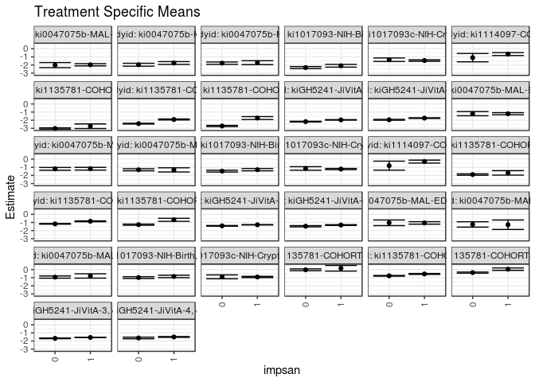

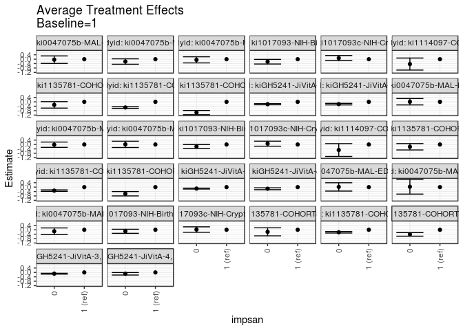

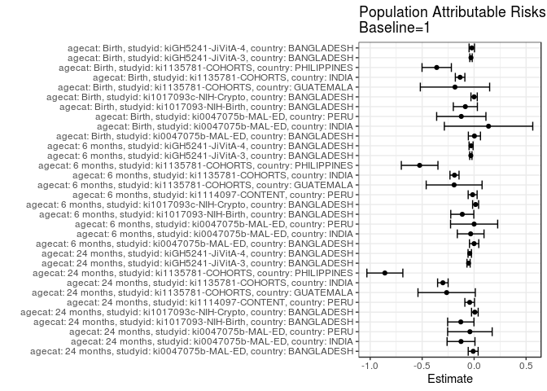

## Results Table

### Parameter: TSM

| agecat | studyid | country | intervention_level | baseline_level | estimate | ci_lower | ci_upper |
| --- | --- | --- | --- | --- | --- | --- | --- |
| Birth | ki0047075b-MAL-ED | BANGLADESH | 1 | NA | -1.0559540 | -1.2067597 | -0.9051483 |
| Birth | ki0047075b-MAL-ED | BANGLADESH | 0 | NA | -1.0379750 | -1.3829233 | -0.6930267 |
| Birth | ki0047075b-MAL-ED | INDIA | 1 | NA | -1.2763689 | -1.8561817 | -0.6965562 |
| Birth | ki0047075b-MAL-ED | INDIA | 0 | NA | -1.2406660 | -1.5713901 | -0.9099419 |
| Birth | ki0047075b-MAL-ED | PERU | 1 | NA | -0.7898433 | -1.0571048 | -0.5225819 |
| Birth | ki0047075b-MAL-ED | PERU | 0 | NA | -0.9260934 | -1.0648454 | -0.7873414 |
| Birth | ki1017093-NIH-Birth | BANGLADESH | 1 | NA | -0.8466802 | -0.9985783 | -0.6947820 |
| Birth | ki1017093-NIH-Birth | BANGLADESH | 0 | NA | -0.9841829 | -1.0927540 | -0.8756118 |
| Birth | ki1017093c-NIH-Crypto | BANGLADESH | 1 | NA | -0.9130605 | -0.9880661 | -0.8380548 |
| Birth | ki1017093c-NIH-Crypto | BANGLADESH | 0 | NA | -0.8938480 | -1.1313327 | -0.6563632 |
| Birth | ki1135781-COHORTS | GUATEMALA | 1 | NA | 0.1564617 | -0.1887981 | 0.5017214 |
| Birth | ki1135781-COHORTS | GUATEMALA | 0 | NA | -0.0309533 | -0.1447852 | 0.0828785 |
| Birth | ki1135781-COHORTS | INDIA | 1 | NA | -0.5428672 | -0.5988613 | -0.4868731 |
| Birth | ki1135781-COHORTS | INDIA | 0 | NA | -0.7698395 | -0.8126409 | -0.7270381 |
| Birth | ki1135781-COHORTS | PHILIPPINES | 1 | NA | 0.0462300 | -0.1016531 | 0.1941132 |
| Birth | ki1135781-COHORTS | PHILIPPINES | 0 | NA | -0.3732475 | -0.4420343 | -0.3044607 |
| Birth | kiGH5241-JiVitA-3 | BANGLADESH | 1 | NA | -1.5597506 | -1.5821193 | -1.5373818 |
| Birth | kiGH5241-JiVitA-3 | BANGLADESH | 0 | NA | -1.6732492 | -1.7100300 | -1.6364684 |
| Birth | kiGH5241-JiVitA-4 | BANGLADESH | 1 | NA | -1.5011947 | -1.5573656 | -1.4450239 |
| Birth | kiGH5241-JiVitA-4 | BANGLADESH | 0 | NA | -1.6252883 | -1.7245676 | -1.5260091 |
| 6 months | ki0047075b-MAL-ED | BANGLADESH | 1 | NA | -1.2027102 | -1.3342617 | -1.0711587 |
| 6 months | ki0047075b-MAL-ED | BANGLADESH | 0 | NA | -1.1937253 | -1.4520080 | -0.9354426 |
| 6 months | ki0047075b-MAL-ED | INDIA | 1 | NA | -1.1754624 | -1.3423377 | -1.0085871 |
| 6 months | ki0047075b-MAL-ED | INDIA | 0 | NA | -1.1943148 | -1.3654950 | -1.0231345 |
| 6 months | ki0047075b-MAL-ED | PERU | 1 | NA | -1.3197094 | -1.5757446 | -1.0636741 |
| 6 months | ki0047075b-MAL-ED | PERU | 0 | NA | -1.3062864 | -1.4319490 | -1.1806238 |
| 6 months | ki1017093-NIH-Birth | BANGLADESH | 1 | NA | -1.2936763 | -1.4351690 | -1.1521836 |
| 6 months | ki1017093-NIH-Birth | BANGLADESH | 0 | NA | -1.4748022 | -1.5866641 | -1.3629402 |
| 6 months | ki1017093c-NIH-Crypto | BANGLADESH | 1 | NA | -1.2174294 | -1.2933991 | -1.1414597 |
| 6 months | ki1017093c-NIH-Crypto | BANGLADESH | 0 | NA | -1.1432348 | -1.3603737 | -0.9260958 |
| 6 months | ki1114097-CONTENT | PERU | 1 | NA | -0.2997094 | -0.4794460 | -0.1199729 |
| 6 months | ki1114097-CONTENT | PERU | 0 | NA | -0.8032722 | -1.3583728 | -0.2481717 |
| 6 months | ki1135781-COHORTS | GUATEMALA | 1 | NA | -1.6866533 | -1.9622147 | -1.4110919 |
| 6 months | ki1135781-COHORTS | GUATEMALA | 0 | NA | -1.8923082 | -1.9801359 | -1.8044805 |
| 6 months | ki1135781-COHORTS | INDIA | 1 | NA | -0.8527126 | -0.9058056 | -0.7996197 |
| 6 months | ki1135781-COHORTS | INDIA | 0 | NA | -1.1701209 | -1.2116659 | -1.1285760 |
| 6 months | ki1135781-COHORTS | PHILIPPINES | 1 | NA | -0.6701556 | -0.8555631 | -0.4847480 |
| 6 months | ki1135781-COHORTS | PHILIPPINES | 0 | NA | -1.2700025 | -1.3405233 | -1.1994817 |
| 6 months | kiGH5241-JiVitA-3 | BANGLADESH | 1 | NA | -1.2819311 | -1.3076215 | -1.2562406 |
| 6 months | kiGH5241-JiVitA-3 | BANGLADESH | 0 | NA | -1.4131211 | -1.4538809 | -1.3723613 |
| 6 months | kiGH5241-JiVitA-4 | BANGLADESH | 1 | NA | -1.3147487 | -1.3565945 | -1.2729028 |
| 6 months | kiGH5241-JiVitA-4 | BANGLADESH | 0 | NA | -1.4619493 | -1.5392638 | -1.3846348 |
| 24 months | ki0047075b-MAL-ED | BANGLADESH | 1 | NA | -1.9694281 | -2.1086891 | -1.8301672 |
| 24 months | ki0047075b-MAL-ED | BANGLADESH | 0 | NA | -2.0116079 | -2.3217532 | -1.7014626 |
| 24 months | ki0047075b-MAL-ED | INDIA | 1 | NA | -1.7520376 | -1.9207584 | -1.5833167 |
| 24 months | ki0047075b-MAL-ED | INDIA | 0 | NA | -1.9638732 | -2.1428547 | -1.7848917 |
| 24 months | ki0047075b-MAL-ED | PERU | 1 | NA | -1.7130552 | -1.9526690 | -1.4734415 |
| 24 months | ki0047075b-MAL-ED | PERU | 0 | NA | -1.7715202 | -1.9141331 | -1.6289073 |
| 24 months | ki1017093-NIH-Birth | BANGLADESH | 1 | NA | -2.0910162 | -2.2612313 | -1.9208011 |
| 24 months | ki1017093-NIH-Birth | BANGLADESH | 0 | NA | -2.3178215 | -2.4429577 | -2.1926853 |
| 24 months | ki1017093c-NIH-Crypto | BANGLADESH | 1 | NA | -1.4488273 | -1.5408017 | -1.3568529 |
| 24 months | ki1017093c-NIH-Crypto | BANGLADESH | 0 | NA | -1.3494622 | -1.5657452 | -1.1331791 |
| 24 months | ki1114097-CONTENT | PERU | 1 | NA | -0.6535970 | -0.8329365 | -0.4742574 |
| 24 months | ki1114097-CONTENT | PERU | 0 | NA | -1.0935404 | -1.6104508 | -0.5766300 |
| 24 months | ki1135781-COHORTS | GUATEMALA | 1 | NA | -2.7408015 | -3.0243010 | -2.4573020 |
| 24 months | ki1135781-COHORTS | GUATEMALA | 0 | NA | -3.0163384 | -3.0905140 | -2.9421628 |
| 24 months | ki1135781-COHORTS | INDIA | 1 | NA | -1.9120163 | -1.9739733 | -1.8500593 |
| 24 months | ki1135781-COHORTS | INDIA | 0 | NA | -2.4224280 | -2.4736236 | -2.3712325 |
| 24 months | ki1135781-COHORTS | PHILIPPINES | 1 | NA | -1.7351020 | -1.9138880 | -1.5563160 |
| 24 months | ki1135781-COHORTS | PHILIPPINES | 0 | NA | -2.7118230 | -2.7836861 | -2.6399598 |
| 24 months | kiGH5241-JiVitA-3 | BANGLADESH | 1 | NA | -1.9602727 | -1.9917703 | -1.9287752 |
| 24 months | kiGH5241-JiVitA-3 | BANGLADESH | 0 | NA | -2.1750257 | -2.2220138 | -2.1280376 |
| 24 months | kiGH5241-JiVitA-4 | BANGLADESH | 1 | NA | -1.7384754 | -1.7793625 | -1.6975884 |
| 24 months | kiGH5241-JiVitA-4 | BANGLADESH | 0 | NA | -1.9467126 | -2.0065947 | -1.8868305 |

### Parameter: E(Y)

| agecat | studyid | country | intervention_level | baseline_level | estimate | ci_lower | ci_upper |
| --- | --- | --- | --- | --- | --- | --- | --- |
| Birth | ki0047075b-MAL-ED | BANGLADESH | NA | NA | -1.0530516 | -1.1896058 | -0.9164975 |
| Birth | ki0047075b-MAL-ED | INDIA | NA | NA | -1.1375000 | -1.4325178 | -0.8424822 |
| Birth | ki0047075b-MAL-ED | PERU | NA | NA | -0.9131731 | -1.0331160 | -0.7932301 |
| Birth | ki1017093-NIH-Birth | BANGLADESH | NA | NA | -0.9310197 | -1.0197391 | -0.8423003 |
| Birth | ki1017093c-NIH-Crypto | BANGLADESH | NA | NA | -0.9131068 | -0.9851939 | -0.8410197 |
| Birth | ki1135781-COHORTS | GUATEMALA | NA | NA | -0.0275356 | -0.1359303 | 0.0808590 |
| Birth | ki1135781-COHORTS | INDIA | NA | NA | -0.6777115 | -0.7106054 | -0.6448175 |
| Birth | ki1135781-COHORTS | PHILIPPINES | NA | NA | -0.3137364 | -0.3764483 | -0.2510244 |
| Birth | kiGH5241-JiVitA-3 | BANGLADESH | NA | NA | -1.5898288 | -1.6090823 | -1.5705753 |
| Birth | kiGH5241-JiVitA-4 | BANGLADESH | NA | NA | -1.5236135 | -1.5727559 | -1.4744711 |
| 6 months | ki0047075b-MAL-ED | BANGLADESH | NA | NA | -1.2026806 | -1.3203025 | -1.0850586 |
| 6 months | ki0047075b-MAL-ED | INDIA | NA | NA | -1.2087268 | -1.3282418 | -1.0892117 |
| 6 months | ki0047075b-MAL-ED | PERU | NA | NA | -1.3196229 | -1.4293681 | -1.2098778 |
| 6 months | ki1017093-NIH-Birth | BANGLADESH | NA | NA | -1.4073821 | -1.4960598 | -1.3187043 |
| 6 months | ki1017093c-NIH-Crypto | BANGLADESH | NA | NA | -1.2031037 | -1.2749632 | -1.1312442 |
| 6 months | ki1114097-CONTENT | PERU | NA | NA | -0.3139217 | -0.4868486 | -0.1409948 |
| 6 months | ki1135781-COHORTS | GUATEMALA | NA | NA | -1.8789210 | -1.9609921 | -1.7968498 |
| 6 months | ki1135781-COHORTS | INDIA | NA | NA | -1.0414424 | -1.0741113 | -1.0087734 |
| 6 months | ki1135781-COHORTS | PHILIPPINES | NA | NA | -1.1942936 | -1.2608624 | -1.1277248 |
| 6 months | kiGH5241-JiVitA-3 | BANGLADESH | NA | NA | -1.3134804 | -1.3366079 | -1.2903528 |
| 6 months | kiGH5241-JiVitA-4 | BANGLADESH | NA | NA | -1.3440477 | -1.3813060 | -1.3067894 |
| 24 months | ki0047075b-MAL-ED | BANGLADESH | NA | NA | -1.9783962 | -2.1050210 | -1.8517715 |
| 24 months | ki0047075b-MAL-ED | INDIA | NA | NA | -1.8779556 | -2.0033207 | -1.7525904 |
| 24 months | ki0047075b-MAL-ED | PERU | NA | NA | -1.7535204 | -1.8760973 | -1.6309435 |
| 24 months | ki1017093-NIH-Birth | BANGLADESH | NA | NA | -2.2190579 | -2.3217459 | -2.1163699 |
| 24 months | ki1017093c-NIH-Crypto | BANGLADESH | NA | NA | -1.4417097 | -1.5263855 | -1.3570340 |
| 24 months | ki1114097-CONTENT | PERU | NA | NA | -0.6962195 | -0.8674103 | -0.5250287 |
| 24 months | ki1135781-COHORTS | GUATEMALA | NA | NA | -3.0050840 | -3.0758338 | -2.9343342 |
| 24 months | ki1135781-COHORTS | INDIA | NA | NA | -2.2126633 | -2.2518337 | -2.1734929 |
| 24 months | ki1135781-COHORTS | PHILIPPINES | NA | NA | -2.5937576 | -2.6629996 | -2.5245156 |
| 24 months | kiGH5241-JiVitA-3 | BANGLADESH | NA | NA | -2.0136975 | -2.0413718 | -1.9860232 |
| 24 months | kiGH5241-JiVitA-4 | BANGLADESH | NA | NA | -1.7803708 | -1.8158650 | -1.7448765 |

### Parameter: ATE

| agecat | studyid | country | intervention_level | baseline_level | estimate | ci_lower | ci_upper |
| --- | --- | --- | --- | --- | --- | --- | --- |
| Birth | ki0047075b-MAL-ED | BANGLADESH | 1 | 1 | 0.0000000 | 0.0000000 | 0.0000000 |
| Birth | ki0047075b-MAL-ED | BANGLADESH | 0 | 1 | 0.0179790 | -0.3594914 | 0.3954494 |
| Birth | ki0047075b-MAL-ED | INDIA | 1 | 1 | 0.0000000 | 0.0000000 | 0.0000000 |
| Birth | ki0047075b-MAL-ED | INDIA | 0 | 1 | 0.0357029 | -0.6340803 | 0.7054861 |
| Birth | ki0047075b-MAL-ED | PERU | 1 | 1 | 0.0000000 | 0.0000000 | 0.0000000 |
| Birth | ki0047075b-MAL-ED | PERU | 0 | 1 | -0.1362501 | -0.4381607 | 0.1656606 |
| Birth | ki1017093-NIH-Birth | BANGLADESH | 1 | 1 | 0.0000000 | 0.0000000 | 0.0000000 |
| Birth | ki1017093-NIH-Birth | BANGLADESH | 0 | 1 | -0.1375027 | -0.3233960 | 0.0483905 |
| Birth | ki1017093c-NIH-Crypto | BANGLADESH | 1 | 1 | 0.0000000 | 0.0000000 | 0.0000000 |
| Birth | ki1017093c-NIH-Crypto | BANGLADESH | 0 | 1 | 0.0192125 | -0.2291402 | 0.2675652 |
| Birth | ki1135781-COHORTS | GUATEMALA | 1 | 1 | 0.0000000 | 0.0000000 | 0.0000000 |
| Birth | ki1135781-COHORTS | GUATEMALA | 0 | 1 | -0.1874150 | -0.5518771 | 0.1770472 |
| Birth | ki1135781-COHORTS | INDIA | 1 | 1 | 0.0000000 | 0.0000000 | 0.0000000 |
| Birth | ki1135781-COHORTS | INDIA | 0 | 1 | -0.2269723 | -0.2971313 | -0.1568133 |
| Birth | ki1135781-COHORTS | PHILIPPINES | 1 | 1 | 0.0000000 | 0.0000000 | 0.0000000 |
| Birth | ki1135781-COHORTS | PHILIPPINES | 0 | 1 | -0.4194775 | -0.5818413 | -0.2571138 |
| Birth | kiGH5241-JiVitA-3 | BANGLADESH | 1 | 1 | 0.0000000 | 0.0000000 | 0.0000000 |
| Birth | kiGH5241-JiVitA-3 | BANGLADESH | 0 | 1 | -0.1134986 | -0.1532521 | -0.0737451 |
| Birth | kiGH5241-JiVitA-4 | BANGLADESH | 1 | 1 | 0.0000000 | 0.0000000 | 0.0000000 |
| Birth | kiGH5241-JiVitA-4 | BANGLADESH | 0 | 1 | -0.1240936 | -0.2367062 | -0.0114810 |
| 6 months | ki0047075b-MAL-ED | BANGLADESH | 1 | 1 | 0.0000000 | 0.0000000 | 0.0000000 |
| 6 months | ki0047075b-MAL-ED | BANGLADESH | 0 | 1 | 0.0089849 | -0.2811316 | 0.2991014 |
| 6 months | ki0047075b-MAL-ED | INDIA | 1 | 1 | 0.0000000 | 0.0000000 | 0.0000000 |
| 6 months | ki0047075b-MAL-ED | INDIA | 0 | 1 | -0.0188524 | -0.2588053 | 0.2211005 |
| 6 months | ki0047075b-MAL-ED | PERU | 1 | 1 | 0.0000000 | 0.0000000 | 0.0000000 |
| 6 months | ki0047075b-MAL-ED | PERU | 0 | 1 | 0.0134230 | -0.2722865 | 0.2991324 |
| 6 months | ki1017093-NIH-Birth | BANGLADESH | 1 | 1 | 0.0000000 | 0.0000000 | 0.0000000 |
| 6 months | ki1017093-NIH-Birth | BANGLADESH | 0 | 1 | -0.1811259 | -0.3603171 | -0.0019347 |
| 6 months | ki1017093c-NIH-Crypto | BANGLADESH | 1 | 1 | 0.0000000 | 0.0000000 | 0.0000000 |
| 6 months | ki1017093c-NIH-Crypto | BANGLADESH | 0 | 1 | 0.0741946 | -0.1552768 | 0.3036661 |
| 6 months | ki1114097-CONTENT | PERU | 1 | 1 | 0.0000000 | 0.0000000 | 0.0000000 |
| 6 months | ki1114097-CONTENT | PERU | 0 | 1 | -0.5035628 | -1.0850990 | 0.0779734 |
| 6 months | ki1135781-COHORTS | GUATEMALA | 1 | 1 | 0.0000000 | 0.0000000 | 0.0000000 |
| 6 months | ki1135781-COHORTS | GUATEMALA | 0 | 1 | -0.2056549 | -0.4950416 | 0.0837318 |
| 6 months | ki1135781-COHORTS | INDIA | 1 | 1 | 0.0000000 | 0.0000000 | 0.0000000 |
| 6 months | ki1135781-COHORTS | INDIA | 0 | 1 | -0.3174083 | -0.3840740 | -0.2507426 |
| 6 months | ki1135781-COHORTS | PHILIPPINES | 1 | 1 | 0.0000000 | 0.0000000 | 0.0000000 |
| 6 months | ki1135781-COHORTS | PHILIPPINES | 0 | 1 | -0.5998469 | -0.7985739 | -0.4011199 |
| 6 months | kiGH5241-JiVitA-3 | BANGLADESH | 1 | 1 | 0.0000000 | 0.0000000 | 0.0000000 |
| 6 months | kiGH5241-JiVitA-3 | BANGLADESH | 0 | 1 | -0.1311901 | -0.1732525 | -0.0891276 |
| 6 months | kiGH5241-JiVitA-4 | BANGLADESH | 1 | 1 | 0.0000000 | 0.0000000 | 0.0000000 |
| 6 months | kiGH5241-JiVitA-4 | BANGLADESH | 0 | 1 | -0.1472006 | -0.2340661 | -0.0603352 |
| 24 months | ki0047075b-MAL-ED | BANGLADESH | 1 | 1 | 0.0000000 | 0.0000000 | 0.0000000 |
| 24 months | ki0047075b-MAL-ED | BANGLADESH | 0 | 1 | -0.0421798 | -0.3830504 | 0.2986908 |
| 24 months | ki0047075b-MAL-ED | INDIA | 1 | 1 | 0.0000000 | 0.0000000 | 0.0000000 |
| 24 months | ki0047075b-MAL-ED | INDIA | 0 | 1 | -0.2118356 | -0.4571332 | 0.0334620 |
| 24 months | ki0047075b-MAL-ED | PERU | 1 | 1 | 0.0000000 | 0.0000000 | 0.0000000 |
| 24 months | ki0047075b-MAL-ED | PERU | 0 | 1 | -0.0584650 | -0.3361184 | 0.2191885 |
| 24 months | ki1017093-NIH-Birth | BANGLADESH | 1 | 1 | 0.0000000 | 0.0000000 | 0.0000000 |
| 24 months | ki1017093-NIH-Birth | BANGLADESH | 0 | 1 | -0.2268053 | -0.4354713 | -0.0181392 |
| 24 months | ki1017093c-NIH-Crypto | BANGLADESH | 1 | 1 | 0.0000000 | 0.0000000 | 0.0000000 |
| 24 months | ki1017093c-NIH-Crypto | BANGLADESH | 0 | 1 | 0.0993651 | -0.1348031 | 0.3335333 |
| 24 months | ki1114097-CONTENT | PERU | 1 | 1 | 0.0000000 | 0.0000000 | 0.0000000 |
| 24 months | ki1114097-CONTENT | PERU | 0 | 1 | -0.4399434 | -0.9868372 | 0.1069504 |
| 24 months | ki1135781-COHORTS | GUATEMALA | 1 | 1 | 0.0000000 | 0.0000000 | 0.0000000 |
| 24 months | ki1135781-COHORTS | GUATEMALA | 0 | 1 | -0.2755369 | -0.5683374 | 0.0172636 |
| 24 months | ki1135781-COHORTS | INDIA | 1 | 1 | 0.0000000 | 0.0000000 | 0.0000000 |
| 24 months | ki1135781-COHORTS | INDIA | 0 | 1 | -0.5104117 | -0.5910910 | -0.4297325 |
| 24 months | ki1135781-COHORTS | PHILIPPINES | 1 | 1 | 0.0000000 | 0.0000000 | 0.0000000 |
| 24 months | ki1135781-COHORTS | PHILIPPINES | 0 | 1 | -0.9767210 | -1.1693463 | -0.7840956 |
| 24 months | kiGH5241-JiVitA-3 | BANGLADESH | 1 | 1 | 0.0000000 | 0.0000000 | 0.0000000 |
| 24 months | kiGH5241-JiVitA-3 | BANGLADESH | 0 | 1 | -0.2147530 | -0.2661761 | -0.1633298 |
| 24 months | kiGH5241-JiVitA-4 | BANGLADESH | 1 | 1 | 0.0000000 | 0.0000000 | 0.0000000 |
| 24 months | kiGH5241-JiVitA-4 | BANGLADESH | 0 | 1 | -0.2082372 | -0.2790920 | -0.1373824 |

### Parameter: PAR

| agecat | studyid | country | intervention_level | baseline_level | estimate | ci_lower | ci_upper |
| --- | --- | --- | --- | --- | --- | --- | --- |
| Birth | ki0047075b-MAL-ED | BANGLADESH | 1 | NA | 0.0029024 | -0.0553008 | 0.0611055 |
| Birth | ki0047075b-MAL-ED | INDIA | 1 | NA | 0.1388689 | -0.2864999 | 0.5642377 |
| Birth | ki0047075b-MAL-ED | PERU | 1 | NA | -0.1233298 | -0.3603596 | 0.1137001 |
| Birth | ki1017093-NIH-Birth | BANGLADESH | 1 | NA | -0.0843396 | -0.2001295 | 0.0314503 |
| Birth | ki1017093c-NIH-Crypto | BANGLADESH | 1 | NA | -0.0000463 | -0.0304530 | 0.0303603 |
| Birth | ki1135781-COHORTS | GUATEMALA | 1 | NA | -0.1839973 | -0.5174260 | 0.1494314 |
| Birth | ki1135781-COHORTS | INDIA | 1 | NA | -0.1348443 | -0.1806953 | -0.0889932 |
| Birth | ki1135781-COHORTS | PHILIPPINES | 1 | NA | -0.3599664 | -0.5011077 | -0.2188251 |
| Birth | kiGH5241-JiVitA-3 | BANGLADESH | 1 | NA | -0.0300782 | -0.0417712 | -0.0183853 |
| Birth | kiGH5241-JiVitA-4 | BANGLADESH | 1 | NA | -0.0224187 | -0.0482686 | 0.0034311 |
| 6 months | ki0047075b-MAL-ED | BANGLADESH | 1 | NA | 0.0000297 | -0.0447291 | 0.0447884 |
| 6 months | ki0047075b-MAL-ED | INDIA | 1 | NA | -0.0332644 | -0.1617386 | 0.0952099 |
| 6 months | ki0047075b-MAL-ED | PERU | 1 | NA | 0.0000864 | -0.2265473 | 0.2267201 |
| 6 months | ki1017093-NIH-Birth | BANGLADESH | 1 | NA | -0.1137058 | -0.2246661 | -0.0027455 |
| 6 months | ki1017093c-NIH-Crypto | BANGLADESH | 1 | NA | 0.0143257 | -0.0144910 | 0.0431424 |
| 6 months | ki1114097-CONTENT | PERU | 1 | NA | -0.0142123 | -0.0572675 | 0.0288430 |
| 6 months | ki1135781-COHORTS | GUATEMALA | 1 | NA | -0.1922677 | -0.4611398 | 0.0766045 |
| 6 months | ki1135781-COHORTS | INDIA | 1 | NA | -0.1887297 | -0.2323747 | -0.1450848 |
| 6 months | ki1135781-COHORTS | PHILIPPINES | 1 | NA | -0.5241381 | -0.7002827 | -0.3479934 |
| 6 months | kiGH5241-JiVitA-3 | BANGLADESH | 1 | NA | -0.0315493 | -0.0423981 | -0.0207005 |
| 6 months | kiGH5241-JiVitA-4 | BANGLADESH | 1 | NA | -0.0292990 | -0.0485279 | -0.0100701 |
| 24 months | ki0047075b-MAL-ED | BANGLADESH | 1 | NA | -0.0089681 | -0.0567343 | 0.0387981 |
| 24 months | ki0047075b-MAL-ED | INDIA | 1 | NA | -0.1259180 | -0.2601115 | 0.0082756 |
| 24 months | ki0047075b-MAL-ED | PERU | 1 | NA | -0.0404652 | -0.2547032 | 0.1737729 |
| 24 months | ki1017093-NIH-Birth | BANGLADESH | 1 | NA | -0.1280417 | -0.2546637 | -0.0014196 |
| 24 months | ki1017093c-NIH-Crypto | BANGLADESH | 1 | NA | 0.0071175 | -0.0248342 | 0.0390693 |
| 24 months | ki1114097-CONTENT | PERU | 1 | NA | -0.0426225 | -0.0891003 | 0.0038552 |
| 24 months | ki1135781-COHORTS | GUATEMALA | 1 | NA | -0.2642825 | -0.5400909 | 0.0115260 |
| 24 months | ki1135781-COHORTS | INDIA | 1 | NA | -0.3006470 | -0.3512910 | -0.2500029 |
| 24 months | ki1135781-COHORTS | PHILIPPINES | 1 | NA | -0.8586556 | -1.0317061 | -0.6856050 |
| 24 months | kiGH5241-JiVitA-3 | BANGLADESH | 1 | NA | -0.0534248 | -0.0686355 | -0.0382140 |
| 24 months | kiGH5241-JiVitA-4 | BANGLADESH | 1 | NA | -0.0418953 | -0.0583114 | -0.0254792 |